# Capitulo 3 - Estadistica 2

## 3.2 **Medidas de variabilidad**

Además de las medidas de posición, con frecuencia es conveniente considerar las medidas de variabilidad o dispersión.

** Histogramas que muestran los tiempos de graduación de los estudiantes**

```python
import matplotlib.pyplot as plt

# Datos de Ingeniería de Sistemas
is_tiempos = [10, 20, 25, 30, 35, 40, 45, 50]

# Datos de Derecho
d_tiempos = [5, 10, 15, 20, 25]

# Figura
fig, ax = plt.subplots(1, 2, figsize=(12, 5))

# Histograma de Ingeniería de Sistemas
ax[0].hist(is_tiempos, bins=4, color='#5CCB5f', edgecolor='black', width=5, alpha=0.5)
ax[0].set_title('Ingeniería de Sistemas')
ax[0].set_xlabel('Tiempo de graduación (años)', fontsize=10, fontweight='bold')
ax[0].set_ylabel('Frecuancia relativa', fontsize=10, fontweight='bold')
#Color de fondo
ax[0].set_facecolor('#D4F8B7')

# Histograma de Derecho
ax[1].hist(d_tiempos, bins=3, color='#5CCB5f', edgecolor='black', width=5, alpha=0.5)
ax[1].set_title('Derecho')
ax[1].set_xlabel('Tiempo de graduación (años)', fontsize=10, fontweight='bold')
ax[1].set_ylabel('Frecuancia relativa', fontsize=10, fontweight='bold')
#Color de fondo
ax[1].set_facecolor('#D4F8B7')



fig = plt.gcf()
fig.patch.set_facecolor('#D4F8B7')

# Mostrar la figura
plt.show()
```

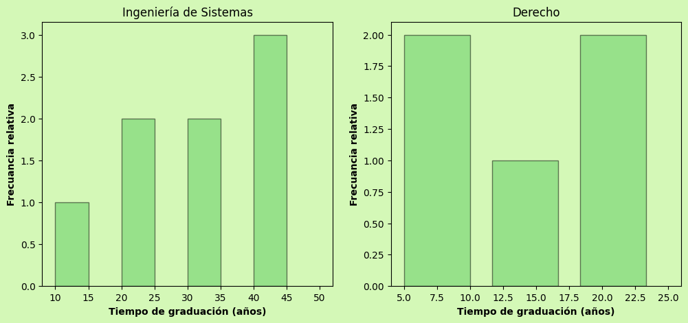

Como se puede observar, los histogramas muestran que la distribución de los tiempos de graduación de los estudiantes de Ingeniería de Sistemas es más dispersa que la distribución de los tiempos de graduación de los estudiantes de Derecho.

Ahora se verá a la revisión de algunas medidas de variabilidad de uso común.

### **Rango**

La medida de variabilidad más sencilla es el **rango**.

RANGO

$$Rango = valor mayor - valor menor$$

**Ejemplo:** Según un estudio realizado por el Instituto Nacional de Estadística de Bolivia (INE) en 2022.

Hombres

- Altura minima: 1,52 metros
- Altura maxima: 1,80 metros

Mujeres

- Altura minima: 1,45 metros
- Altura maxima: 1,61 metros

RANGO

Rango = valor mayor - valor menor

RANGO HOMBRES

RANGO MUJERES

Rango mujeres = 161 cm - 145 cm = 16 cm

En este caso, el rango de altura para los hombres es de 28 centímetros, mientras que el rango para las mujeres es de 16 centímetros.

### Ejercicios

```python
%%html
<!DOCTYPE html>
<html lang="es">
<head>
    <meta charset="UTF-8">
    <meta name="viewport" content="width=device-width, initial-scale=1.0">
    <title>Rango Intercuartílico</title>
</head>
<body>

   <button onclick="generarNumeros()" type="button" style="background-color:#009929">Generar Ejercicio</button>

    <p id="numerosAleatorios">_</p>

    <label for="inputMayor">Ingresa el valor mayor:</label>
    <input type="number" id="inputMayor" required style="background-color: #D4F8B7;">
    <label for="inputMenor">Ingresa el valor menor:</label>
    <input type="number" id="inputMenor" required style="background-color: #D4F8B7;">
    <label for="inputRango">Ingresa el rango:</label>
    <input type="number" id="inputRango" required style="background-color: #D4F8B7;">

    <button onclick="verificar() "type="button" style="background-color:#009929">Verificar</button>
    <p id="resultado"><br></p>

    <script>
        var numerosAleatorios = [];

        function generarNumeros() {
            // Generar 10 números aleatorios entre 1 y 100
            numerosAleatorios = [];
            for (var i = 0; i < 10; i++) {
                numerosAleatorios.push(Math.floor(Math.random() * 100) + 1);
            }

            // Mostrar los números aleatorios generados
            document.getElementById("numerosAleatorios").innerText = "Considere una muestra con los datos  " + numerosAleatorios.join(", ");
        }

        function verificar() {
            // Obtener valores ingresados por el usuario
            var numeroMayor = parseInt(document.getElementById("inputMayor").value);
            var numeroMenor = parseInt(document.getElementById("inputMenor").value);
            var rangoEsperado = parseInt(document.getElementById("inputRango").value);

            // Verificar si los números generados cumplen con los criterios
            var rangoCalculado = Math.max(...numerosAleatorios) - Math.min(...numerosAleatorios);

            var resultado = "";

            if (rangoCalculado === rangoEsperado && Math.max(...numerosAleatorios) === numeroMayor && Math.min(...numerosAleatorios) === numeroMenor) {
                resultado += "<strong>¡Verificación exitosa!</strong>";
            } else {
                resultado += "<strong> Verificación fallida. Por favor, verifica los valores ingresados.</strong>";
            }

            // Mostrar los resultados en el documento HTML
            document.getElementById("resultado").innerHTML = resultado;
        }
    </script>

</body>
</html>
```

### **Rango intercuartílico**

Una medida de la variabilidad que supera la dependencia sobre los valores extremos es el **rango intercuartílico (RIC)**. Esta medida de la variabilidad es la diferencia entre el tercer cuartil, $Q_3$, y el primer cuartil, $Q_1$. En otras palabras, el rango intercuartílico es el rango de la media de $50\%$ de los datos.

RANGO INTERCUARTÍLICO

$$RIC = Q_3 - Q_1$$

(3.3)

**Ejemplo: **

Para calcular el RIC, primero se deben ordenar los datos de menor a mayor. Luego, se encuentran $Q_1$ y $Q_3$. $Q_1$ es el valor que divide la mitad inferior de los datos en dos partes iguales. $Q_3$ es el valor que divide la mitad superior de los datos en dos partes iguales.

Por ejemplo, si un conjunto de datos tiene los siguientes valores:

$$1, 2, 3, 4, 5, 6, 7, 8, 9, 10$$

$Q_1$ es igual a 3 y $Q_3$ es igual a 8. Por lo tanto, el RIC es igual a 5:

RANGO INTERCUARTILICO

$$RIC = Q_3 - Q_1$$
$$RIC = 8 - 3 = 5$$

El RIC se puede interpretar como el rango de valores que abarcan el 50% central de los datos. En el ejemplo anterior, el 50% de los datos se encuentran entre 3 y 8.

### Ejercicios

```python
%%html
<!DOCTYPE html>
<html lang="es">
<head>
    <meta charset="UTF-8">
    <meta name="viewport" content="width=device-width, initial-scale=1.0">
    <title>Rango Intercuartílico</title>
</head>
<body>
    <button onclick="generarNumeros()" type="button" style="background-color:#009929">Generar Números</button>

    <p id="numerosAleatorios"></p>

    <label for="inputMayor">Ingresa Q<sub>3</sub>:</label>
    <input type="number" id="inputMayor" required style="background-color: #D4F8B7;">
    <label for="inputMenor">Ingresa Q<sub>1</sub>:</label>
    <input type="number" id="inputMenor" required style="background-color: #D4F8B7;">
    <label for="inputRango">Ingresa el rango intercuartilico:</label>
    <input type="number" id="inputRango" required style="background-color: #D4F8B7;">

    <button onclick="verificar()" type="button" style="background-color:#009929">Verificar</button>
    <p id="resultado"><br></p>

    <script>
        var numerosAleatorios = [];

        function generarNumeros() {
            // Generar 10 números aleatorios entre 1 y 100
            numerosAleatorios = [];
            for (var i = 0; i < 10; i++) {
                numerosAleatorios.push(Math.floor(Math.random() * 100) + 1);
            }

            // Mostrar los números aleatorios generados
            document.getElementById("numerosAleatorios").innerText = "Números aleatorios generados: " + numerosAleatorios.join(", ");
        }

        function verificar() {
            // Obtener valores ingresados por el usuario
            var numeroMayor = parseInt(document.getElementById("inputMayor").value);
            var numeroMenor = parseInt(document.getElementById("inputMenor").value);
            var rangoEsperado = parseInt(document.getElementById("inputRango").value);

            // Verificar si los números generados cumplen con los criterios
            // Ordenar los datos
            var datosOrdenados = numerosAleatorios.slice().sort(function(a, b) {
                return a - b;
            });

            var Q1 = datosOrdenados[2];
            var Q3 = datosOrdenados[7];

            var iqrCalculado = Q3-Q1;

            var resultado = "";

            if (iqrCalculado === rangoEsperado && Q3 === numeroMayor && Q1 === numeroMenor) {
                resultado += "<strong>¡Verificación exitosa!</strong>";
            } else {
                resultado += "<strong>Verificación fallida. Por favor, verifica los valores ingresados.</strong>";
            }

            // Mostrar los resultados en el documento HTML
            document.getElementById("resultado").innerHTML = resultado;
        }

    </script>

</body>
</html>
```

### **Varianza**

```python
from IPython.display import YouTubeVideo

youtube_video = YouTubeVideo('YRfpblzLTrA')

display(youtube_video)
```

[video not shown]

La **varianza** es una medida de la variabilidad que utiliza todos los datos. Se basa en la diferencia entre el valor de cada observación $(x_i)$ y la media. La diferencia entre cada $x_i$ y la media($\overline{x}$ para una muestra; μ para una población) se llama desviación respecto de la media. Para una muestra, una desviación respecto de la media se escribe ($x_i$ - $\overline{x}$); para una población, se escribe ($x_i$ - μ). Si se desea calcular la varianza, las desviaciones respecto de la media se elevan al cuadrado.

### **Varianza Poblacional**

Si los datos pertenecen a una población, el promedio de las desviaciones elevadas al cuadrado se llama varianza poblacional, la cual se denota por medio del símbolo griego $σ_2$. Para una población de N observaciones con una media poblacional μ, la definición de la varianza poblacional es la siguiente.

VARIANZA POBLACIONAL

$$\sigma^2 = \frac{\sum(x_i-\mu)^2}{N}$$

(3.4)

donde:

- $ \sigma^2 $ es la varianza poblacional.
- $ x_i $ es un dato de la población.
- $ \mu $ es la media poblacional.
- $ N $ es el tamaño de la población.

```python
import matplotlib.pyplot as plt
import matplotlib.patches as patches

# Crear la figura y el eje
fig, ax = plt.subplots()

#color
fig.patch.set_facecolor('#D4F8B7')

#formula
ax.text(0.25,0.3,r"$\sigma^2 = \frac{\sum(x_i-\mu)^2}{N}$",fontsize=30)

# Agregar el texto y las flechas
ax.text(0.2, 0.6, 'Varianza poblacional', fontsize=12, ha='center', va='center')
arrow_n = patches.FancyArrowPatch((0.2, 0.56), (0.27, 0.4), mutation_scale=15, color='#5CCB5f')
ax.add_patch(arrow_n)

ax.text(0.4, 0.7, 'Dato de la poblacion', fontsize=12, ha='center', va='center')
arrow_n = patches.FancyArrowPatch((0.4, 0.66), (0.54, 0.44), mutation_scale=15, color='#5CCB5f')
ax.add_patch(arrow_n)

ax.text(0.8, 0.7, 'Media poblacional', fontsize=12, ha='center', va='center')
arrow_mean = patches.FancyArrowPatch((0.8, 0.65), (0.68, 0.44), mutation_scale=15, color='#5CCB5f')
ax.add_patch(arrow_mean)

ax.text(0.8, 0.1, 'Tamaño de la Población', fontsize=12, ha='center', va='center')
arrow_summation = patches.FancyArrowPatch((0.8, 0.15), (0.62, 0.27), mutation_scale=15, color='#5CCB5f')
ax.add_patch(arrow_summation)

# Ajustar límites y mostrar la imagen
ax.set_xlim(0, 1)
ax.set_ylim(0, 0.8)

# Ocultar ejes
ax.axis('off')

plt.show()
```

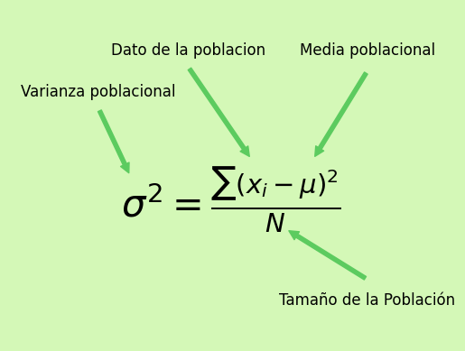

**Ejemplo: **

```python
from IPython.display import YouTubeVideo

youtube_video = YouTubeVideo('A7xDMQ6CQj0')

display(youtube_video)
```

[video not shown]

En la mayoría de las aplicaciones estadísticas, los datos que se analizan provienen de una muestra. Cuando se calcula una varianza muestral, a menudo lo que interesa es usarla para estimar la varianza poblacional $σ^2$.Esta mostrarse que si la suma de las desviaciones respecto de la media al cuadrado se divide entre $n - 1$, y no entre $n$, la varianza muestral resultante proporciona un estimador insesgado de la varianza poblacional. Por esta razón, la varianza muestral, denotada por $s^2$, se define como sigue.

### **Varianza Muestral**

La varianza muestral es una medida estadística que describe la dispersión de un conjunto de datos en relación con la media de una muestra. Se representa comúnmente por el símbolo $s^2$. La fórmula para calcular la varianza muestral es la siguiente:

**Donde:**

- $s^2$ es la varianza muestral.
- $n$ es el tamaño de la muestra.
- $x_i$ son los valores individuales en la muestra.
- $\bar{x}$ es la media de la muestra.

**Ejercicios**

Según la recopilación de datos realizada por la División de Estadística de Delitos contra la Propiedad en Bolivia durante los meses de enero a febrero de 2021, se ha elaborado una tabla que refleja la incidencia de robos agravados. A continuación, utilizaremos los datos proporcionados en esta tabla para calcular la varianza muestral

| Departamento | Robos Agrabados |
| --- | --- |
| Beni | 34 |
| Chuquisaca | 38 |
| Cochabamba | 107 |
| La Paz | 17 |
| Oruro | 11 |
| Pando | 17 |
| Potosí | 25 |
| Santa Cruz | 130 |
| Tarija | 35 |

**Paso 1: Calcular la media $\bar{x}$:**

$ \bar{x} = \frac{34 + 38 + 107 + 17 + 11 + 17 + 25 + 130 + 35}{9} \approx 46 $

**Paso 2: Calcular las diferencias y elevar al cuadrado:**

$ (34 - 46)^2 = 144 $

$ (38 - 46)^2 = 64 $

$ (17 - 46)^2 = 841 $

$ (11 - 46)^2 = 1225 $

$ (17 - 46)^2 = 841 $

$ (25 - 46)^2 = 441 $

$ (35 - 46)^2 = 121 $

Como conclusion, un valor más alto de varianza sugiere una mayor variabilidad en la cantidad de robos agravados entre los departamentos. Esta medida estadística es útil para comprender la amplitud de la distribución y para identificar patrones de variabilidad en los datos.

### **Desviación estándar**

```python
from IPython.display import YouTubeVideo

youtube_video = YouTubeVideo('https://www.youtube.com/watch?v=hLmsEFNaOgY&list=PLeySRPnY35dE25b7mIEUlsMCQqlhJFhyG')

display(youtube_video)
```

[video not shown]

**Desviación estándar muestral**

La desviación estándar muestral es una medida estadística que cuantifica la dispersión o variabilidad de un conjunto de datos en relación con la media muestral. Es particularmente útil para comprender cuán dispersos están los valores individuales con respecto a la media aritmética de la muestra.

La fórmula para la desviación estándar muestral ($s$) es:

**Formula de la Desviacion Estandar Muestral**

**$$s = \sqrt{s^2} $$**

**Donde:**

**Desviacion Estandar Poblacional**

La desviación estándar poblacional es una medida estadística que cuantifica la dispersión o variabilidad de un conjunto de datos en relación con la media poblacional. A diferencia de la desviación estándar muestral, la desviación estándar poblacional utiliza la media de la población en lugar de la media muestral.

La fórmula para la desviación estándar poblacional ($\sigma$) es:

**Formula de la Desviacion Estandar Poblacional**

**$\sigma = \sqrt{\sigma^2}$**

**Donde:**

**Ejercicios**

Calcular la Desvicion estandar muestral del ejemplo mencionado anteriormente.

```python
from IPython.display import YouTubeVideo

youtube_video = YouTubeVideo('A7xDMQ6CQj0')

display(youtube_video)
```

[video not shown]

### **Coeficiente de variación**

El coeficiente de variación es una medida estadística que proporciona información sobre la variabilidad relativa de un conjunto de datos en comparación con su media. Esta medida es especialmente útil cuando se trabaja con diferentes escalas o unidades. La fórmula para calcular el (CV) se expresa como:

$$CV = (\left( \frac{\text{Desviación estándar}}{\text{Media}} \right) \times 100)\%$$

El (CV) se presenta como un porcentaje y cuantifica la dispersión de los datos en relación con su valor promedio, permitiendo una comparación más significativa entre de datos con magnitudes diferentes.

**Ejemplo**

Vamos a utilizar un ejemplo hipotético relacionado con las alturas de estudiantes en dos escuelas diferentes en Bolivia para calcular el coeficiente de variación.

Supongamos que tenemos las alturas de los estudiantes de dos escuelas (en centímetros):

Escuela A: 150, 155, 160, 165, 170 Escuela B: 140, 145, 160, 175, 180

Primero, calculemos el coeficiente de variación utilizando la formula anterior.

```python
import numpy as np
import matplotlib.pyplot as plt

# Alturas de estudiantes en centímetros
alturas_escuela_a = np.array([150, 155, 160, 165, 170])
alturas_escuela_b = np.array([140, 145, 160, 175, 180])

# Calcular la media y la desviación estándar para cada escuela
media_a = np.mean(alturas_escuela_a)
desviacion_estandar_a = np.std(alturas_escuela_a)
cv_a = (desviacion_estandar_a / media_a) * 100

media_b = np.mean(alturas_escuela_b)
desviacion_estandar_b = np.std(alturas_escuela_b)
cv_b = (desviacion_estandar_b / media_b) * 100

# Gráfico comparativo
fig, axs = plt.subplots(1, 2, figsize=(12, 5))

# Escuela A
axs[0].hist(alturas_escuela_a, edgecolor="black", color="#5CCB5F")
axs[0].axvline(x=media_a, color='red', linestyle='dashed', linewidth=2, label=f'Media: {media_a:.2f}')
axs[0].set_title(f"Escuela A CV: {cv_a:.2f}%", color="#5CCB5F")
axs[0].set_xlabel("Alturas (cm)")
axs[0].set_ylabel("Frecuencia relativa")
axs[0].legend()
axs[0].set_facecolor('#D4F8B7')

# Escuela B
axs[1].hist(alturas_escuela_b, edgecolor="black", color="#5CCB5F")
axs[1].axvline(x=media_b, color='red', linestyle='dashed', linewidth=2, label=f'Media: {media_b:.2f}')
axs[1].set_title(f"Escuela B CV: {cv_b:.2f}%", color="#5CCB5F")
axs[1].set_xlabel("Alturas (cm)")
axs[1].set_ylabel("Frecuencia relativa")
axs[1].legend()
axs[1].set_facecolor('#D4F8B7')

# Ajustes generales
fig.patch.set_facecolor('#D4F8B7')
plt.suptitle("Comparación de Alturas de Estudiantes en Escuelas A y B", fontsize=16, color="#5CCB5F")

plt.show()
```

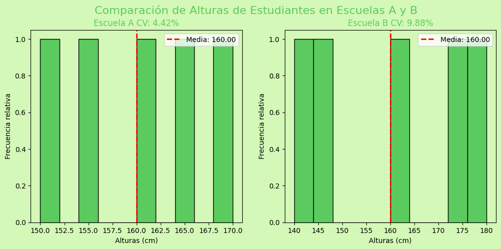

**Escuela A**

En el histograma correspondiente, la línea roja punteada indica la media de las alturas.

**Escuela B**

Nuevamente, en el gráfico de alturas de la Escuela B, la línea roja punteada destaca la media.

**Comparación**

Esta información nos proporciona una comprensión inicial de la dispersión de las alturas en ambas escuelas.

## 3.3 **Medidas de la forma de la distribución, posición relativa y detección de observaciones atípicas**

### **Forma de la distribución**

```python
import numpy as np
import matplotlib.pyplot as plt

# Datos para un histograma sesgado a la derecha
datos_sesgo_derecha = np.random.exponential(scale=2, size=1000)

# Datos para un histograma sesgado a la izquierda
datos_sesgo_izquierda = -np.random.exponential(scale=2, size=1000)

# Datos para un histograma sin sesgo
datos_sin_sesgo = np.random.normal(loc=0, scale=2, size=1000)

# Gráficos
fig, axs = plt.subplots(1, 3, figsize=(15, 5))

# Histograma sesgado a la derecha
axs[0].hist(datos_sesgo_derecha, bins=30, color="#FFD700", edgecolor="black")
axs[0].set_title("Sesgo a la Derecha")
axs[0].set_xlabel("Valores")
axs[0].set_ylabel("Frecuencia relativa")

# Histograma sesgado a la izquierda
axs[1].hist(datos_sesgo_izquierda, bins=30, color="#FFD700", edgecolor="black")
axs[1].set_title("Sesgo a la Izquierda")
axs[1].set_xlabel("Valores")
axs[1].set_ylabel("Frecuencia relativa")

# Histograma sin sesgo
axs[2].hist(datos_sin_sesgo, bins=30, color="#FFD700", edgecolor="black")
axs[2].set_title("Sin Sesgo")
axs[2].set_xlabel("Valores")
axs[2].set_ylabel("Frecuencia relativa")

# Ajustes generales
fig.patch.set_facecolor('#D4F8B7')
plt.suptitle("Ejemplos de Sesgo en Histogramas", fontsize=16, color="#5CCB5F")

plt.show()
```

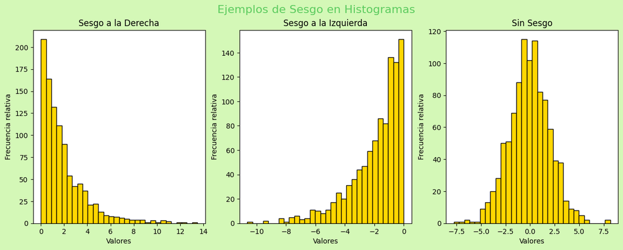

En una distribución simétrica, la media y la mediana son iguales. Cuando los datos están sesgados positivamente, la media por lo general será mayor que la mediana; cuando están sesgados negativamente, la media será menor que la mediana.

### **Valor z**

El valor Z, también conocido como puntaje Z o estadístico Z, es una medida estandarizada que indica cuántas desviaciones estándar un punto de datos está del promedio de un conjunto. Este valor Z es esencial en estadísticas, ya que proporciona una forma de comparar y entender la posición relativa de un dato dentro de una distribución.

El cálculo del valor Z se realiza utilizando la siguiente fórmula: $$Z = \frac{\text{X - μ}}{\text{σ}} $$

donde:

- **X** es el valor individual
- **μ** es la media de la población
- **σ** es la desviación estándar de la población.

Un valor **Z positivo** indica que el dato está por encima de la media, mientras que un valor **Z negativo** indica que está por debajo de la media.

**Ejemplo** **Rendimiento en Exámenes**

- Grupo A:
- Media de puntajes: 75
- Desviación estándar: 10
- Puntaje de Estudiante X en Grupo A: 85
- Grupo B:
- Media de puntajes: 65
- Desviación estándar: 8
- Puntaje de Estudiante Y en Grupo B: 72

```python
import pandas as pd
import numpy as np
import matplotlib.pyplot as plt
from matplotlib.table import Table

# Datos
data = {
    'Grupo': ['A', 'B'],
    'Media': [75, 65],
    'Desviación Estándar': [10, 8],
    'Puntaje del Estudiante': [85, 72],
    'Valor Z del Estudiante': [1, 0.875]
}

# Crear un DataFrame
df = pd.DataFrame(data)

# Crear la figura y los ejes
fig, ax = plt.subplots(figsize=(8, 4))

# Ocultar ejes
ax.set_axis_off()

# Convertir el DataFrame a una tabla de matplotlib
tabla = Table(ax, bbox=[0, 0, 1, 1])

# Ajustar automáticamente el ancho de las columnas
tabla.auto_set_column_width([0, 1, 2, 3, 4])

# Añadir filas y columnas a la tabla
tabla.auto_set_font_size(False)
tabla.set_fontsize(10)
tabla.scale(1.2, 1.2)  # Ajustar el tamaño de la tabla

# Encabezados de columna
for i, key in enumerate(df.keys()):
    tabla.add_cell(0, i, 0.1, 0.1, text=key, loc='center', facecolor='#5CCB5F')

# Datos y colores
colors = [
    ['#5CCB5F', '#5CCB5F', '#D4F8B7', '#D4F8B7', '#D4F8B7'],
    ['#5CCB5F', '#5CCB5F', '#D4F8B7', '#D4F8B7', '#D4F8B7']
]
for i in range(len(df)):
    for j, key in enumerate(df.keys()):
        tabla.add_cell(i+1, j, 0.1, 0.1, text=str(df.iloc[i, j]), loc='center', facecolor=colors[i][j])

# Añadir la tabla al eje
ax.add_table(tabla)

plt.show()
```

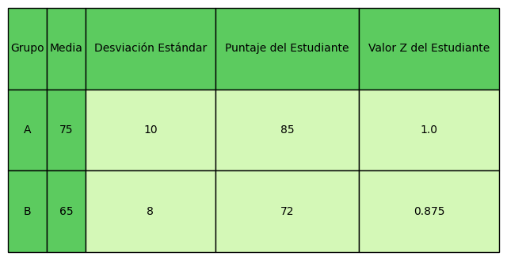

**Para el estudiante X en el Grupo A:**

$$Z = \frac{\text{85 - 75}}{\text{10}} = 1$$

El valor Z de 1 indica que el puntaje del estudiante X está a una desviación estándar por encima de la media del Grupo A.

**Para el estudiante Y en el Grupo B:**

$$Z = \frac{\text{72 - 65}}{\text{8}} = 0.875$$

El valor Z de 0.875 indica que el puntaje del estudiante Y está a aproximadamente 0.88 desviaciones estándar por encima de la media del Grupo B.

Estos valores Z proporcionan una forma estandarizada de comparar el rendimiento relativo de los estudiantes en diferentes grupos.

### **Teorema de Chebyshev**

El Teorema de Chebyshev es un principio estadístico que proporciona información sobre la dispersión de datos en cualquier conjunto de datos, independientemente de su forma de distribución. Este teorema es especialmente útil cuando no conocemos la forma exacta de la distribución de los datos. La formulación general del Teorema de Chebyshev es la siguiente:

Para cualquier conjunto de datos, la proporción de observaciones dentro de $k$ desviaciones estándar de la media es al menos $1 - \frac{\text{1}}{\text{k²}}$ , donde $k > 1.$

En otras palabras, al menos $1 - \frac{\text{1}}{\text{k²}}$ del total de los datos se encuentra dentro de $k$ desviaciones estándar de la media.

```python
import numpy as np
import matplotlib.pyplot as plt
from IPython.display import Image, display

# Generar datos ficticios
np.random.seed(42)
datos = np.random.normal(loc=50, scale=10, size=1000)

# Crear histograma con color de fondo personalizado
fig, ax = plt.subplots()
ax.hist(datos, bins=30, color="#5CCB5F", edgecolor="black")
ax.axvline(np.mean(datos), color='red', linestyle='dashed', linewidth=2, label=f'Media: {np.mean(datos):.2f}')
ax.axvline(np.mean(datos) + 2 * np.std(datos), color='orange', linestyle='dashed', linewidth=2, label='+2 Desviaciones')
ax.axvline(np.mean(datos) - 2 * np.std(datos), color='orange', linestyle='dashed', linewidth=2, label='-2 Desviaciones')
ax.set_title("Teorema de Chebyshev")
ax.set_xlabel("Datos")
ax.set_ylabel("Frecuencia relativa")
ax.legend()

# Configurar el color de fondo
fig.patch.set_facecolor('#D4F8B7')

# Guardar el gráfico como imagen
plt.savefig("teorema_chebyshev.png")

# Mostrar la imagen en Colab
display(Image(filename="teorema_chebyshev.png"))
```

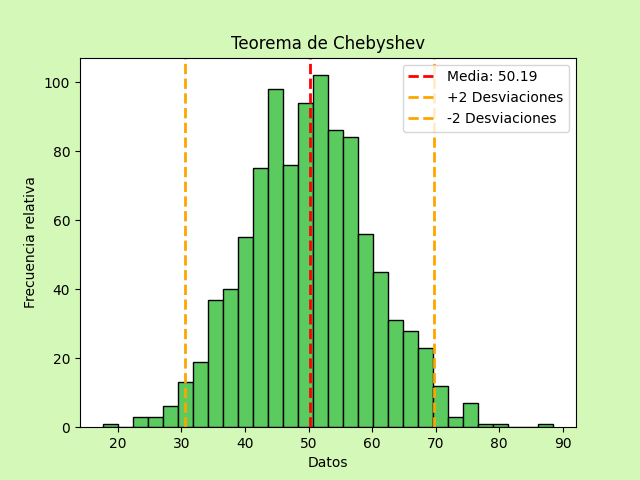

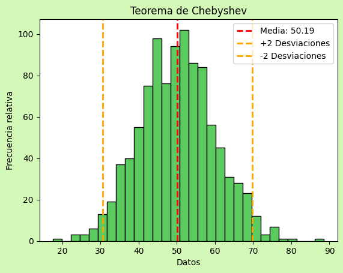

Ten en cuenta que el Teorema de Chebyshev proporciona una estimación conservadora y no precisa de la dispersión de datos, pero es útil en situaciones donde no conocemos la forma exacta de la distribución.

### **Regla empírica**

Una de las ventajas del teorema de Chebyshev estriba en que se aplica a cualquier conjunto de datos sin importar su forma de distribución. De hecho, podría usarse con cualquiera de las distribuciones. Sin embargo, en muchas aplicaciones prácticas los conjuntos de datos exhiben una distribución simétrica con forma de pila o de campana. Cuando se piensa que los datos se aproximan a esta distribución, la regla empírica se usa para determinar el porcentaje de valores de datos que deben estar dentro de un número específico de desviaciones estándar de la media.

```python
import numpy as np
import matplotlib.pyplot as plt

# Generar datos ficticios con una distribución normal
np.random.seed(42)
datos = np.random.normal(loc=0, scale=1, size=1000)

# Crear histograma con color de fondo personalizado
fig, ax = plt.subplots()
n, bins, patches = ax.hist(datos, bins=30, density=True, color="#5CCB5F", edgecolor="black", alpha=0.7)

# Ajustar la curva de campana (distribución normal)
from scipy.stats import norm
media, desviacion_estandar = np.mean(datos), np.std(datos)
x = np.linspace(min(bins), max(bins), 100)
y = norm.pdf(x, media, desviacion_estandar)
ax.plot(x, y, 'k--', linewidth=2)

# Configurar el color de fondo
fig.patch.set_facecolor('#D4F8B7')

# Configurar etiquetas y título
ax.set_title("Distribución Normal (Campana de Gauss)", fontsize=16, color="#5CCB5F")
ax.set_xlabel("Datos")
ax.set_ylabel("Densidad de Probabilidad")

# Mostrar el gráfico
plt.show()
```

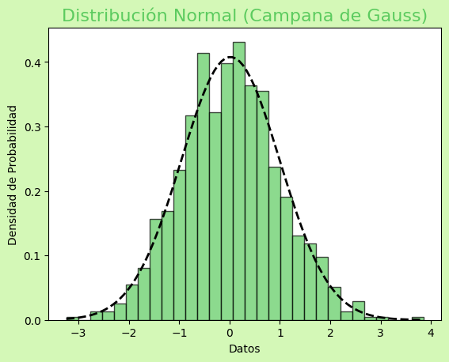

### **Detección de observaciones atípicas**

Un conjunto de datos a veces tiene una o más observaciones con valores inusualmente grandes o sumamente pequeños. Estos valores extremos se llaman **observaciones atípicas**. Los expertos en estadística experimentados emprenden acciones para identificar observaciones atípicas y luego revisan cada una con detalle. Una observación atípica suele ser un valor de datos que se registró incorrectamente; si esto ocurre, el error se corrige antes de un análisis posterior. También puede ser una observación que se introdujo de forma incorrecta en el conjunto de datos; si este es el caso, se elimina.

Por último, puede consistir en un valor de datos inusual que se registró correctamente y pertenece al conjunto de datos. En tal caso, debe conservarse. Los valores estandarizados (puntuaciones z), se utilizan para identificar observaciones atípicas. Recuerde que la regla empírica permite concluir que cuando los datos tienen una dis- tribución en forma de campana, casi todos los valores de datos están dentro de tres desviaciones estándar de la media. Por tanto, al usar puntuaciones z para identificar observaciones extremas, se recomienda tomar en cuenta como una observación atípica cualquier valor de datos con una puntuación z menor que -3 o mayor que +3. La exactitud de estos valores debe verificarse y determinar si pertenecen al conjunto de datos.

**Ejemplo**

```python
import numpy as np
import matplotlib.pyplot as plt

# Generar datos ficticios con algunos valores atípicos
np.random.seed(42)
datos = np.concatenate([np.random.normal(0, 1, 50), np.random.normal(10, 1, 5)])

# Crear un gráfico de caja
fig, ax = plt.subplots()
ax.boxplot(datos, vert=False, widths=0.7, patch_artist=True, medianprops={'color': 'red'})

# Configurar el color de fondo
fig.patch.set_facecolor('#D4F8B7')

# Configurar etiquetas y título
ax.set_title("Gráfico de Caja con Observaciones Atípicas", fontsize=16, color="#5CCB5F")
ax.set_xlabel("Datos")

# Mostrar el gráfico
plt.show()
```

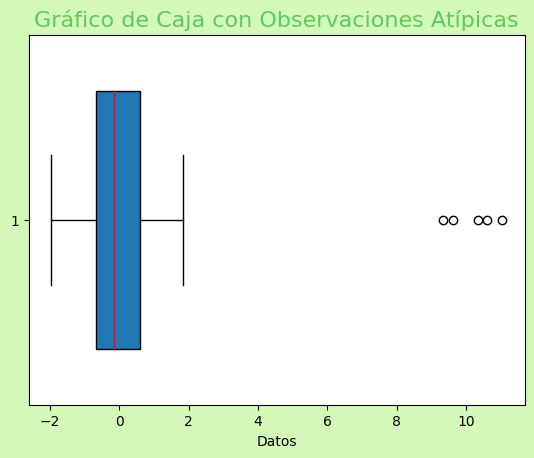

En este ejemplo, observamos un conjunto de datos con 50 valores normales distribuidos alrededor de 0 y 5 valores atípicos distribuidos alrededor de 10.

## 3.4 **Análisis exploratorio de datos**

En el capítulo 2 se introdujo el diagrama de tallo y hoja como una técnica de análisis exploratorio de datos. Recuerde que dicho análisis permite usar operaciones aritméticas simples y representaciones gráficas fáciles de dibujar para resumir los datos. En esta sección continúa el análisis exploratorio de datos considerando resúmenes de cinco números y diagramas de caja.

### **Resumen de cinco números**

En un resumen de cinco números, los cinco siguientes se usan para resumir los datos.

- Valor menor
- Primer cuartil $(Q_1)$
- Mediana $(Q_2)$
- Tercer cuartil $(Q_3)$
- Valor mayor

**Ejemplo**

### **Diagrama de caja**

Un diagrama de caja es un resumen gráfico de los datos basado en un resumen de cinco nú- meros. La clave para elaborar de un diagrama de caja es el cálculo de la mediana y los cuartiles $Q_1$ y $Q_3$. El rango intercuartílico $RIC = Q_3 - Q_1$.

**Los pasos que se siguen para elaborarlo se presentan a continuación.**

- Se traza una caja con sus extremos ubicados en el primer y tercer cuartiles.
- Se traza una línea vertical en el cuadro donde se ubica la mediana.
- Al usar el rango intercuartílico, se localizan los límites.
- Usando las líneas punteadas se trazan desde los extremos de la caja hasta los valores menor y mayor dentro de los límites calculados en el paso 3.
- Por último, la ubicación de cada observación atípica se señala con un asterisco.

**Ejemplo**

```python
import numpy as np
import seaborn as sns
import matplotlib.pyplot as plt

# Generar datos ficticios con algunos valores atípicos
np.random.seed(42)
datos = np.concatenate([np.random.normal(0, 1, 50), np.random.normal(10, 1, 5)])

# Crear un diagrama de caja con Seaborn
sns.set(style="whitegrid")
fig, ax = plt.subplots(figsize=(8, 6))

# Configurar el color de fondo
fig.patch.set_facecolor('#D4F8B7')

# Crear el diagrama de caja
sns.boxplot(x=datos, color="#5CCB5F", width=0.5)

# Agregar puntos atípicos
sns.stripplot(x=datos, color="red", size=8, jitter=0.3)

# Configurar etiquetas y título
ax.set_title("Diagrama de Caja con Observaciones Atípicas", fontsize=16, color="#5CCB5F")
ax.set_xlabel("Datos")

# Mostrar el gráfico
plt.show()
```

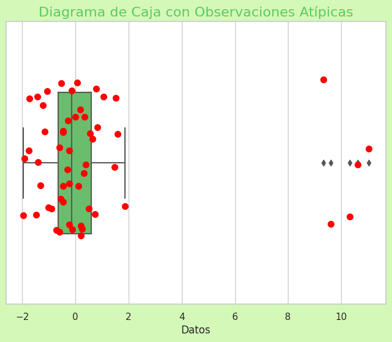

## 3.5 **Medidas de asociación entre dos variables**

Hasta ahora hemos examinado los métodos numéricos que resumen los datos de una variable a la vez. Un gerente o quien toma decisiones se interesa con frecuencia en la relación entre dos variables. En esta sección se presentan la covarianza y la correlación como medidas descriptivas de la relación entre dos variables.

### **Covarianza**

**Covarianza Muestral**

La covarianza muestral es una medida estadística que evalúa la relación lineal entre dos variables aleatorias en una muestra de datos. Proporciona información sobre la dirección de la relación **(positiva o negativa)**. En el contexto de la estadística, la covarianza es un indicador de cómo cambian dos variables juntas.

La fórmula de la covarianza muestral $$s_{xy}$$ entre dos variables **X** e **Y** en una muestra de datos es:

$$s_{xy} = \frac{\sum_{i=1}^{n} (x_i - \bar{X})(y_i - \bar{Y})}{n-1}$$

donde:

- n es el tamaño de la muestra
- $$x_i \text{ y } y_i$$ son los valores individuales de las dos variables en la muestra
- $$\bar{X} \text{ y } \bar{Y}$$ son las medias muestrales de las dos variables, respectivamente

La covarianza toma valores **positivos** cuando las variables tienden a aumentar o disminuir juntas, **negativos** cuando una variable tiende a aumentar mientras que la otra disminuye, y **cercanos a cero** cuando no hay una clara relación lineal entre las variables.

Es importante destacar que la covarianza muestral puede ser afectada por la escala de las variables, lo cual puede dificultar su interpretación. Por esta razón, se utiliza a menudo el coeficiente de correlación, que es la covarianza normalizada, para proporcionar una medida más estandarizada de la relación entre dos variables.

**Ejemplo**

Covarianza Muestral en Bolivia

En el contexto de un estudio sobre diferentes regiones de Bolivia, hemos recopiladolos siguientes datos sobre el ingreso per cápita (en dólares) y la tasa de alfabetización (en porcentaje) en cinco regiones diferentes. Queremos entender cómo estas dos variables se relacionan entre sí.

```python
import numpy as np
import matplotlib.pyplot as plt
from tabulate import tabulate

# Datos ficticios
ingreso_per_capita = np.array([5000, 6000, 4500, 7000, 5500])
tasa_alfabetizacion = np.array([85, 88, 78, 92, 80])

# Calcular las medias muestrales
media_ingreso = np.mean(ingreso_per_capita)
media_alfabetizacion = np.mean(tasa_alfabetizacion)

# Calcular la covarianza muestral
covarianza_muestral = np.cov(ingreso_per_capita, tasa_alfabetizacion, ddof=1)[0, 1]

# Crear la tabla con colores
tabla_info = [
    ["", "Media", "Covarianza Muestral"],
    ["Ingreso Per Cápita", f"{media_ingreso:.2f}", ""],
    ["Tasa de Alfabetización", f"{media_alfabetizacion:.2f}", f"{covarianza_muestral:.2f}"]
]

# Mostrar la tabla en la consola con colores
print(tabulate(tabla_info, headers="firstrow", tablefmt="fancy_grid", colalign=("center", "center", "center")))

# Graficar los datos con el color de fondo #D4F8B7
fig, ax = plt.subplots()
ax.scatter(ingreso_per_capita, tasa_alfabetizacion, color='#5CCB5F', edgecolor="black")
ax.set_xlabel('Ingreso Per Cápita')
ax.set_ylabel('Tasa de Alfabetización')
ax.axhline(y=media_alfabetizacion, color='red', linestyle='dashed', linewidth=2, label=f'Media Alfabetización: {media_alfabetizacion:.2f}')
ax.axvline(x=media_ingreso, color='blue', linestyle='dashed', linewidth=2, label=f'Media Ingreso: {media_ingreso:.2f}')
ax.legend()
ax.set_facecolor('#D4F8B7')
fig.patch.set_facecolor('#D4F8B7')
plt.suptitle("Dispersión entre Ingreso Per Cápita y Tasa de Alfabetización", fontsize=16, color="#5CCB5F")

plt.show()
```

```
╒════════════════════════╤═════════╤═══════════════════════╕
│                        │  Media  │  Covarianza Muestral  │
╞════════════════════════╪═════════╪═══════════════════════╡
│   Ingreso Per Cápita   │  5600   │                       │
├────────────────────────┼─────────┼───────────────────────┤
│ Tasa de Alfabetización │  84.6   │        4800.00        │
╘════════════════════════╧═════════╧═══════════════════════╛
```

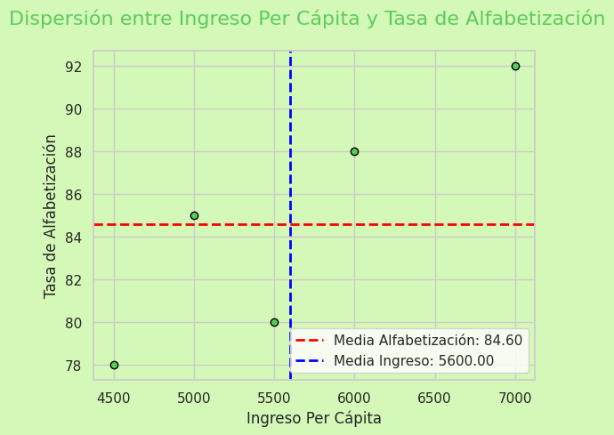

**Covarianza Poblacional**

La covarianza poblacional es una medida estadística que evalúa la relación lineal entre dos variables en una población completa. A diferencia de la covarianza muestral, que utiliza datos de una muestra específica, la covarianza poblacional considera todos los individuos en la población. Esta medida proporciona información valiosa sobre la dirección y fuerza de la relación entre dos variables aleatorias.

La fórmula de covarianza poblacional $$σ_{xy}$$ entre dos variables **X** e **Y** en una población se expresa como:

$$σ_{xy} = \frac{\sum_{i=1}^{N} (x_i - μ_x)(y_i - μ_y)}{N}$$

donde:

- N es el tamaño total de la población
- $$x_i \text{ y } y_i$$ son los valores individuales de las dos variables de la población
- $$μ_x \text{ y } μ_y$$ son las medias poblacionales de las dos variables

La covarianza poblacional toma valores **positivos** cuando las variables tienden a aumentar o disminuir juntas, valores **negativos** cuando una variable tiende a aumentar mientras que la otra disminuye, y **cerca de cero** cuando no hay una clara relación lineal entre las variables.

Es importante tener en cuenta que la covarianza poblacional puede ser utilizada para calcular el coeficiente de correlación poblacional, que normaliza la covarianza y proporciona una medida estandarizada de la fuerza y dirección de la relación entre dos variables en toda la población.

**Ejemplo**

**Horas de estudio semanal (en horas)** horas_estudio = [10, 12, 8, 15, 11]

**Rendimiento académico en el examen (en porcentaje)** rendimiento_examen = [75, 80, 65, 90, 78]

Primero, calculamos las medias poblacionales $$μ_x = \frac{\sum_{i=1}^{N} (x_i)}{N}$$ $$μ_y = \frac{\sum_{i=1}^{N} (y_i)}{N}$$

Supongamos que N=5 en este caso.

```python
import numpy as np
import matplotlib.pyplot as plt

# Datos ficticios
horas_estudio = np.array([10, 12, 8, 15, 11])
rendimiento_examen = np.array([75, 80, 65, 90, 78])

# Calcular las medias poblacionales
media_horas_estudio = np.mean(horas_estudio)
media_rendimiento_examen = np.mean(rendimiento_examen)

# Calcular la covarianza poblacional
covarianza_poblacional = np.cov(horas_estudio, rendimiento_examen)[0, 1]

# Crear un scatter plot
plt.figure(figsize=(8, 6))
plt.scatter(horas_estudio, rendimiento_examen, color='blue', label='Datos')

# Línea que indica la dirección de la relación
plt.plot([media_horas_estudio, media_horas_estudio], [media_rendimiento_examen, media_rendimiento_examen + covarianza_poblacional], color='red', linestyle='--', linewidth=2, label='Dirección de la relación')

# Etiquetas y título
plt.xlabel('Horas de Estudio Semanal')
plt.ylabel('Rendimiento en el Examen (%)')
plt.title("Relación entre Horas de Estudio y Rendimiento en el Examen", fontsize=16, color="#5CCB5F")

# Establecer el color de fondo
plt.gca().set_facecolor('#D4F8B7')

# Mostrar la leyenda
plt.legend()

# Mostrar el gráfico
plt.show()
```

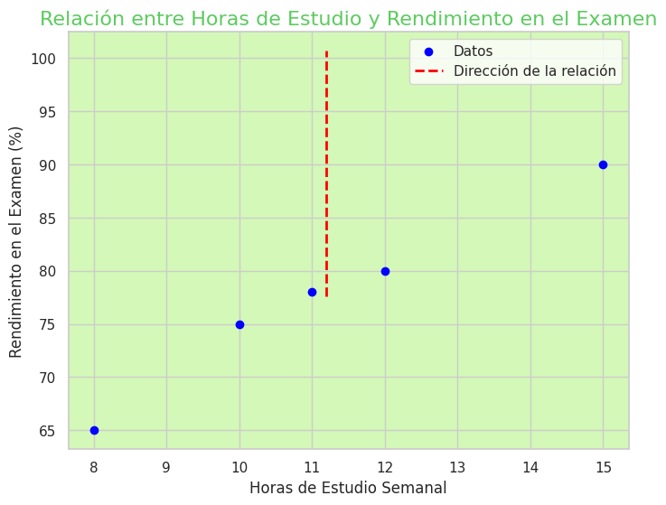

### **Coeficiente de correlación**

Para los datos muestrales, el coeficiente de correlación del producto-momento de Pearson se define como se indica a continuación.

COEFICIENTE DE CORRELACIÓN DEL PRODUCTO-MOMENTO DE PEARSON: DATOS MUESTRALES

$$r_{xy} = \frac{S_{xy}}{S_xS_y}$$

(3.12)

Donde:

- $r_{xy}$ = coeficiente de correlación muestral  
- $s_{xy}$ = covarianza muestral  
- $s_x$ = desviación estándar muestral de x  
- $s_y$ = desviación estándar muestral de y

COEFICIENTE DE CORRELACIÓN DEL PRODUCTO-MOMENTO DE PEARSON: DATOS POBLACIONALES

$$\rho_{xy} =\frac{\sigma_{xy}}{\sigma_x \sigma_y}$$

(3.13)

Donde:

- $\rho_{xy}$ = coeficiente de correlación poblacional  
- $ \sigma_{xy}$ = covarianza poblacional  
- $ \sigma_x$ = desviación estándar poblacional de x  
- $ \sigma_y$ = desviación estándar poblacional de y

**Ejemplo**

```python
import numpy as np
import matplotlib.pyplot as plt

# Datos
np.random.seed(42)
x = np.random.rand(100) * 10  # Variable independiente
y = 2 * x + 1 + np.random.randn(100) * 2  # Variable dependiente con ruido

# Calcular el coeficiente de correlación (Pearson)
coef_corr = np.corrcoef(x, y)[0, 1]

# Crear un gráfico de dispersión
plt.scatter(x, y, color="#5CCB5F", label=f"Coeficiente de Correlación: {coef_corr:.2f}")

# Configurar el color de fondo
plt.gcf().patch.set_facecolor('#D4F8B7')

# Configurar etiquetas y título
plt.title("Gráfico de Dispersión con Coeficiente de Correlación", fontsize=16, color="#5CCB5F")
plt.xlabel("Variable Independiente")
plt.ylabel("Variable Dependiente")
plt.legend()

# Mostrar el gráfico
plt.show()
```

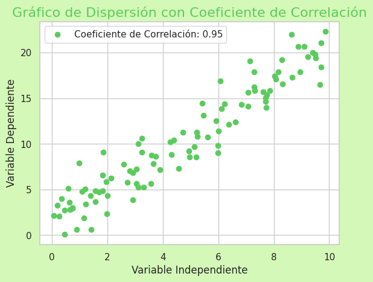

En este ejemplo, existen dos conjuntos de datos relacionados linealmente. El coeficiente de correlación de Pearson se calcula utilizando np.corrcoef, y luego se visualiza el gráfico de dispersión de los datos con el coeficiente de correlación en la leyenda. Este es un ejemplo positivo de correlación, ya que el coeficiente debería estar cerca de 1 debido a la relación lineal entre x e y.

## 3.6 **Media ponderada y trabajo con datos agrupados**

En la sección 3.1 se presentó la media como una de las medidas más importantes de ubicación central. La fórmula para la media de una muestra con n observaciones se vuelve a establecer como sigue.

MEDIA MUESTRAL

$$ \bar{x} = \frac{\sum x_i}{n}$$

En esta fórmula, cada $x_i$ recibe igual importancia o peso. Aunque esta práctica es la más común, en algunos casos la media se calcula confiriendo a cada observación un peso que refleje su importancia. Una media calculada de esta manera se conoce como media ponderada.

### **Media ponderada**

La media ponderada se calcula como sigue.

MEDIA PONDERADA

$$ \bar{x} = \frac{\sum (w_i*x_i)}{\sum (w_i)}$$

(3.15)

Donde:

- $x_i$ = valor de observación $i$  
- $w_i$ = peso de la observación $i$

**Ejemplo**

**Compra de materia prima**

| Compra | Costo(Bs) | Numero de Libras |
| --- | --- | --- |
| 1 | 3.00 | 1200 |
| 2 | 3.40 | 500 |
| 3 | 2.80 | 2750 |
| 4 | 2.90 | 1000 |
| 5 | 3.25 | 800 |

$$ \bar{x} = \frac{1 200(3.00) + 500(3.40) + 2 750(2.80) + 1 000(2.90) + 800(3.25)}{1 200 + 500 + 2 750 + 1 000 + 800} $$

$$ \bar{x} = \frac{18500}{6250} $$

$$ \bar{x} = 2.96 $$

Por tanto, el cálculo de la media ponderada indica que el costo medio por libra para la materia prima es $2.96(Bs)$.

### **Datos agrupados**

En la mayoría de los casos, las medidas de posición y variabilidad se calculan con valores de datos individuales. No obstante, los datos en ocasiones están disponibles sólo en forma agrupada o en forma de distribución de frecuencia. En el análisis siguiente se explica cómo usar la fórmula de la media ponderada para obtener aproximaciones de la media, la varianza y la desviación estándar para datos agrupados.

### **Media Muestral para Datos Agrupados**

La media muestral para datos agrupados es una medida estadística que proporciona una estimación de la tendencia central de un conjunto de datos que ha sido organizado en intervalos o clases. Esta medida se denota comúnmente por $\bar{x}$ y se calcula teniendo en cuenta la frecuencia de cada intervalo.

La fórmula general para calcular la media muestral para datos agrupados es:

$$ \bar{x} = \frac{\sum_{i=1}^{k} f_i \cdot m_i}{N} $$

**Donde:**

- $\bar{x}$ representa la media muestral.
- $k$ es el número de intervalos o clases.
- $f_i$ es la frecuencia del i-ésimo intervalo.
- $m_i$ es la marca de clase del i-ésimo intervalo (el punto medio del intervalo).
- $N$ es el tamaño total de la muestra (la suma de todas las frecuencias).

El cálculo implica multiplicar cada marca de clase por su frecuencia correspondiente, sumar estos productos y luego dividir por el tamaño total de la muestra. Esta fórmula proporciona una estimación de la media de la población basada en la información agrupada en intervalos.

Es esencial tener en cuenta que, al trabajar con datos agrupados, la media muestral proporciona una medida de la tendencia central del conjunto de datos, pero pierde detalle sobre las observaciones individuales dentro de cada intervalo. Es una herramienta útil para resumir datos agrupados de manera más compacta.

**Ejercicios**

Tenemos los siguientes datos agrupados en intervalos para el número de ventas mensuales en la tienda de MANACO de las ventas de cada empleado:

| Intervalo de Ventas | Frecuencia |
| --- | --- |
| 10 - 20 | 5 |
| 20 - 30 | 12 |
| 30 - 40 | 8 |
| 40 - 50 | 15 |
| 50 - 60 | 10 |

**Paso 1: Calcular la Marca de Clase $m_i$**

La marca de clase $m_i$ se encuentra tomando el punto medio de cada intervalo. Para el primer intervalo, por ejemplo, sería (10 + 20) / 2 = 15. Haces esto para cada intervalo.

**Paso 2: Calcular $f_i \cdot m_i$ para cada intervalo:**

Multiplicas la frecuencia $f_i$ por la marca de clase $m_i$ para cada intervalo.

**Paso 3: Sumar $f_i \cdot m_i$ para todos los intervalos:**

Sumas los productos obtenidos en el paso anterior.

| Intervalo de Ventas | Frecuencia | Marca de Clase fi | fi * mi |
| --- | --- | --- | --- |
| 10 - 20 | 5 | 15 | 75 |
| 20 - 30 | 12 | 25 | 300 |
| 30 - 40 | 8 | 35 | 280 |
| 40 - 50 | 15 | 45 | 675 |
| 50 - 60 | 10 | 55 | 550 |

**Paso 4: Calcular la Media Muestral $\bar{x}$:**

Utilizas la fórmula de la media muestral:

$$ \bar{x} = \frac{\sum_{i=1}^{k} f_i \cdot m_i}{N} $$

**Paso 5: Suma de $f_i \cdot m_i$:**

$75 + 300 + 280 + 675 + 550 = 1880$

**Paso 6: Número total de observaciones $N$:**

$5 + 12 + 8 + 15 + 10 = 50$

**Paso 7: Media Muestral $\bar{x}$:**

$\frac{1880}{50} = 37.6$

**Gráfico**

```python
import matplotlib.pyplot as plt

# Datos
intervalos = ['10-20', '20-30', '30-40', '40-50', '50-60']
frecuencias = [5, 12, 8, 15, 10]
marcas_de_clase = [15, 25, 35, 45, 55]

# Calcular la media muestral
suma_fi_mi = sum([f * m for f, m in zip(frecuencias, marcas_de_clase)])
suma_fi = sum(frecuencias)
media_muestral = suma_fi_mi / suma_fi

# Configurar colores
color_fondo = '#D4F8B7'
color_barras = '#8CC084'
color_media = 'red'

# Crear el gráfico de barras con personalizaciones
fig, ax = plt.subplots()
bars = ax.bar(marcas_de_clase, frecuencias, width=8, align='center', alpha=0.7, color=color_barras, label='Frecuencia')
ax.scatter(media_muestral, max(frecuencias), color=color_media, marker='x', s=100, label='Media Muestral')

# Establecer el fondo de color
fig.patch.set_facecolor(color_fondo)
ax.set_facecolor(color_fondo)

# Etiquetas y título
ax.set_xlabel('Marca de Clase')
ax.set_ylabel('Frecuencia')
ax.set_title('Histograma con Media Muestral')
ax.legend()

# Mostrar la media muestral en la consola
print(f'Media Muestral: {media_muestral}')

# Mostrar el gráfico
plt.show()
```

```
Media Muestral: 37.6
```

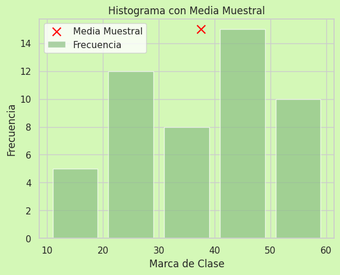

### **Varianza Muestral para Datos Agrupados**

La varianza muestral para datos agrupados es una medida estadística que proporciona una estimación de la variabilidad o dispersión de un conjunto de datos agrupados alrededor de la media muestral. La fórmula para calcular la varianza muestral en el caso de datos agrupados se deriva teniendo en cuenta la estructura de intervalos o clases en los que se agrupan los datos.

La fórmula general para la varianza muestral de datos agrupados es:

$s^2 = \frac{\sum_{i=1}^{k} f_i \cdot (m_i - \bar{x})^2}{N - 1}$

**Donde:**

- $k$ es el número de intervalos o clases.
- $f_i$ es la frecuencia del i-ésimo intervalo.
- $m_i$ es la marca de clase del i-ésimo intervalo (el punto medio del intervalo).
- $\bar{x}$ es la media muestral.
- $N$ es el tamaño total de la muestra (la suma de todas las frecuencias).

**Ejercicios**

Supongamos que ahora estamos analizando la cantidad de gasto mensual en alimentación de familias en diferentes ciudades de Bolivia. Hemos recopilado los siguientes datos agrupados en intervalos de 200 bolivianos:

| Intervalo de Gasto Mensual (en bolivianos) | Frecuencia |
| --- | --- |
| 0-200 | 10 |
| 200-400 | 15 |
| 400-600 | 20 |
| 600-800 | 12 |
| 800-1000 | 8 |

Supongamos que la media muestral del gasto mensual ($\bar{x}$) es de 500 bolivianos.

**Paso 1: Calcular la clase $m_i$:**

La marca de clase se calcula como el punto medio de cada intervalo. Por ejemplo, para el primer intervalo (0-200):

$ m_1 = \frac{0 + 200}{2} = 100 $

Realizamos este cálculo para todos los intervalos.

**Paso 2: Calcular $\bar{x}$:**

Dado que ya se proporciona la media muestral: $\bar{x} = 500$

**Paso 3: Calcular $ (m_i - \bar{x})^2 $ para cada intervalo:**

$(m_1 - \bar{x})^2 = (100 - 500)^2 = 400^2 = 160000 $

**Paso 4: Multiplicar $ (m_i - \bar{x})^2 $ por la frecuencia $f_i$ para cada intervalo :**

$ f_1 \cdot (m_1 - \bar{x})^2 = 10 \cdot 160000 = 1600000 $

[output not shown]

**Paso 5: Sumar $(m_i - \bar{x})^2$ * $f_i$ para todos los intervalos donde $k$ es igual a 5:**

$\sum_{i=1}^{k} f_i \cdot (m_i - \bar{x})^2 = \sum_{i=1}^{5} f_i \cdot (m_i - \bar{x})^2$

Este valor indica cuánto se alejan, en promedio, los gastos mensuales de cada intervalo del gasto medio muestral. Cuanto mayor sea la varianza, mayor será la dispersión de los datos. En este caso, la varianza sugiere que hay una variabilidad considerable en los gastos mensuales entre las familias de las diferentes ciudades.

```python
from IPython.display import YouTubeVideo

youtube_video = YouTubeVideo('v8fjSz6PMyk')

display(youtube_video)
```

[video not shown]

### **Media Poblacional para datos agrupados**

La media poblacional para datos agrupados es una medida estadística que representa el valor típico o promedio de una característica en una población cuando los datos se presentan en forma de intervalos o clases. Se calcula utilizando la fórmula:

MEDIA POBLACIONAL PARA DATOS AGRUPADOS

$$\mu = \frac{\sum_{i=1}^{k} f_i \cdot M_i}{N}$$

(3.18)

Donde:

- $\mu$ representa la media poblacional.
- $k$ es el número de intervalos o clases.
- $f_i$ es la frecuencia del i-ésimo intervalo.
- $M_i$ es la marca de clase del i-ésimo intervalo (el punto medio del intervalo).
- $N$ es el tamaño total de la poblacion.

La media muestral para datos agrupados es una estimación de la media poblacional basada en una muestra de la población. Tanto la media poblacional como la media muestral para datos agrupados buscan representar la tendencia central de los datos cuando se presentan en intervalos. La diferencia principal radica en que la media poblacional considera la población completa, mientras que la media muestral se basa en una muestra de la población. Ambas son herramientas importantes en estadística descriptiva y son útiles para entender la distribución de datos agrupados.

### **Varianza Poblacional para datos agrupados**

La varianza poblacional para datos agrupados es una medida estadística que cuantifica la dispersión o variabilidad de una característica en una población cuando los datos están agrupados en intervalos o clases. Se calcula utilizando la fórmula:

VARIANZA POBLACIONAL PARA DATOS AGRUPADOS

$$σ^2 = \frac{\sum_{i=1}^{k} f_i \cdot (M_i - \mu)^2}{N}$$

(3.19)

Donde:

- $k$ es el número de intervalos o clases.
- $f_i$ es la frecuencia del i-ésimo intervalo.
- $M_i$ es la marca de clase del i-ésimo intervalo (el punto medio del intervalo).
- $\mu$ es la media poblacional.
- $N$ es el tamaño total de la muestra.

La varianza muestral para datos agrupados es una estimación de la varianza poblacional basada en una muestra de la población. Utiliza una fórmula similar, pero con las frecuencias relativas de la muestra. La varianza poblacional para datos agrupados mide la dispersión en una población completa, mientras que la varianza muestral para datos agrupados estima esta dispersión basándose en una muestra. Ambas proporcionan información sobre la variabilidad de una característica en datos agrupados.